← Voltar ao Portal

[figure not shown]

Programa 404

# Síntese Avaliativa do Desempenho dos Programas do PPA Bahia 2024–2027

# **1 - Desempenho Global do Programa**

Este documento apresenta uma Síntese Avaliativa do Desempenho do Programa do Plano Plurianual - PPA 2024- 2027, trazendo uma visão estratégica dos seus resultados, de forma sintética, transparente e colaborativa. Serão levados em consideração o Indicador Sintético de Desempenho do Programa (ISDP), a evolução dos Indicadores de Programa, a eficácia das metas dos Indicadores de Compromisso, o desempenho da execução orçamentária-financeira e da execução física das Ações orçamentárias. O ISDP é uma síntese dessas quatro dimensões, destacando o desempenho do programa em relação aos resultados obtidos e aos esforços despendidos.  
Adicionalmente, são apresentados os principais resultados alcançados, evidenciando os avanços e conformidades dos cinco programas com melhores resultados, além das oportunidades de melhoria dos cinco, com menores resultados. Enquanto neste documento a análise abrange o programa e seus componentes de maneira sintética, nos demais relatórios, a análise detalhada evidencia o comportamento dos componentes do PPA por programas e por órgãos (https://www.ba.gov.br/seplan/monitoramento-e-avaliacao/avaliacao-do-ppa). Além desta Síntese, o [Painel BI - Boletim de Avanços e Oportunidades de Melhoria](https://app.powerbi.com/view?r=eyJrIjoiN2Q0ODliNDItZDFjZi00MGM1LTliNGEtODVmZDAwZTQ1OGEyIiwidCI6IjRjZDgzNWY0LTU0NDAtNDA4Zi05M2EzLTk3NWZjMTdjMzg0YSIsImMiOjR9) oferece informações organizadas em uma perspectiva estratégica do desempenho consolidado dos programas, detalhando, no entanto, cada componente avaliado. A análise nesta seção engloba o programa e seus componentes conforme segue:

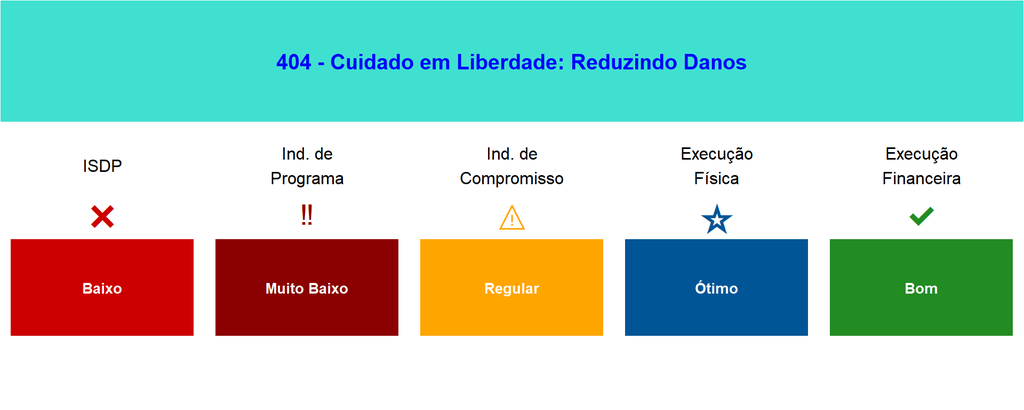

# **2 - Avanços e Conformidades no Programa**

**Indicadores de Programa:** No programa 404 - Cuidado em Liberdade: Reduzindo Danos, nenhum indicador apresentou evolução positiva.  
**Indicadores de Compromisso:** No programa 404 - Cuidado em Liberdade: Reduzindo Danos, 44,4% dos indicadores de compromisso foram classificados como tendo desempenho bom ou ótimo. Destaca-se, em particular, o indicador ‘1 - Número de pessoas atendidas pelas ações de redução de riscos e danos qualificadas profissionalmente’, que atingiu 78,33%. Essa performance pode ser atribuída a um déficit na execução da meta, já que o programa mede não o número de pessoas atendidas, mas sim o número de cursos realizados. Portanto, é necessário solicitar uma revisão no PPA para alinhar as nomenclaturas às métricas adequadas, assegurando maior precisão na avaliação dos resultados. Adicionalmente, outro indicador relevante é ‘1 - Percentual de pessoas atendidas pelas ações de cuidado em liberdade com enfoque na redução de riscos e danos encaminhadas aos serviços públicos’, que alcançou 81,54%. Essa taxa pode ser explicada por uma execução abaixo do previsto da referida meta. No entanto, já estão sendo implementadas medidas de readequação para ajustar as ações e garantir que os objetivos sejam plenamente alcançados nos próximos anos.  
**Ações Orçamentárias:** Para o Programa 404 - Cuidado em Liberdade: Reduzindo Danos, todas as ações foram avaliadas como de bom ou ótimo desempenho, tanto na execução financeira quanto na execução física, resultando em 100%.

# **3 - Oportunidade de Melhoria no Programa**

**Indicadores de Programa:** No Programa 404 - Cuidado em Liberdade: Reduzindo Danos, não houve indicadores aptos para a avaliação. O indicador 2173, que mede a proporção de pessoas que têm uso problemático de álcool e outras drogas e que são atendidas por ações de redução de riscos, não foram disponibilizados dados.  
**Indicadores de Compromisso:** No programa 404 - Cuidado em Liberdade: Reduzindo Danos, 33,3% dos indicadores foram considerados de baixo desempenho, enquanto 11,1% mostraram-se indeterminados. O indicador ‘3 - Número de municípios com ações de redução de riscos’ obteve 22%, abaixo do esperado devido a limitações no planejamento para 2024, que contemplava apenas 9 municípios. Já o indicador ‘1 - Número de pesquisas sobre política de drogas’ alcançou 50%, refletindo a realização de pesquisas planejadas, cuja análise dos resultados deverá ser concluída ao longo dos próximos anos.  
**Ações Orçamentárias:** Para o Programa 404 - Cuidado em Liberdade: Reduzindo Danos, nenhuma das ações foi avaliadas como de baixo ou muito baixo desempenho, tanto na execução financeira quanto na execução física.

Desenvolvido por: DAP – Diretoria de Avaliação de Políticas Públicas